# Simulation tests of multinomial models for use with photo ID data

Introduction:

Photo identification of individuals within a population is a common data source that is becoming more common given technological advances and the use of computer vision and machine learning to re-identify individuals. These data are collected through hand-held cameras, drones, and camera traps, and often come with biases in terms of sampling effort and distribution. In spite of these biases a common goal of collecting these datasets is to better understand the habitat use pattern of individuals and populations. Here, we examine the potential for multilevel binomial models to generate socio-spatial networks that capture the similarities in individual users across the spatial distribution of a species. We use this approach with 18 years of photo-ID data to better understand population structuring of beluga whales in the St. Lawrence River. We show using permuted and simulated data that this approach can identify community network structures within populations in a way that accounts for biases in collections methods. Applying this method to the entire 18 years dataset for SLE beluga, we found three spatially distinct clusters. These results suggest that within the population’s summer range individuals are moving within restricted areas (i.e., home ranges), and have implications for the estimated impacts of localized anthropogenic stressors, such as chemical pollution or acoustic disturbances on animal populations. We conclude that multilevel binomial models can be effective at estimating socio-spatial networks that describe habitat use patterns within wildlife populations.

### Get the observed data

0.1 Load some libraries

```r
library(rgdal)
library(ggplot2)
library(raster)
library(brms)
library(dplyr)
library(igraph)
library(rgeos)
```

## Multilevel binomial models

#### 2.1) completely random data

Retrieve and format the data for the multilevel binomial model

```r
#get data where the sector associcated with a photoID has been randomly permuted
df.mag.sec <- read.csv("../data/photoID_perm.csv")

#for each individual count the number of times seen in each sector
df.mag.sec <- df.mag.sec %>% mutate(sec_ID = paste0(sec,"_",ID) )
df.mag.sec.multinom <- df.mag.sec %>% group_by(ID) %>% dplyr::summarize(y2=sum(sec==2),
                                                                     y3=sum(sec==3),
                                                                     y4=sum(sec==4),
                                                                     y5=sum(sec==5),
                                                                     y6=sum(sec==6),
                                                                     y7=sum(sec==7),
                                                                     y8=sum(sec==8),
                                                                     y9=sum(sec==9),
                                                                     y10=sum(sec==10),
                                                                     y11=sum(sec==11),
                                                                     y12=sum(sec==12),
                                                                     y13=sum(sec==13),
                                                                     y14=sum(sec==14),
                                                                     y15=sum(sec==15))
#for each individual count the total number of times seen
df.mag.sec.multinom$size <- with(df.mag.sec.multinom, y2 + y3 + y4 + y5 + y6 + y7 + y8 + y9 + y10 + y11 + y12 + y13 + y14 + y15)

#rename the dataframe
df.random.multinom<-df.mag.sec.multinom
```

Fit the multilevel multinomial model

```r
#formula for each sector
bf_2 <- bf(y2 | trials(size) ~ 1 + (1|p|ID))+ binomial()
bf_3 <- bf(y3 | trials(size) ~ 1 + (1|p|ID))+ binomial()
bf_4 <- bf(y4 | trials(size) ~ 1 + (1|p|ID))+ binomial()
bf_5 <- bf(y5 | trials(size) ~ 1 + (1|p|ID))+ binomial()
bf_6 <- bf(y6 | trials(size) ~ 1 + (1|p|ID))+ binomial()
bf_7 <- bf(y7 | trials(size) ~ 1 + (1|p|ID))+ binomial()
bf_8 <- bf(y8 | trials(size) ~ 1 + (1|p|ID))+ binomial()
bf_9 <- bf(y9 | trials(size) ~ 1 + (1|p|ID))+ binomial()
bf_10 <- bf(y10 | trials(size) ~ 1 + (1|p|ID))+ binomial()
bf_11 <- bf(y11 | trials(size) ~ 1 + (1|p|ID))+ binomial()
bf_12 <- bf(y12 | trials(size) ~ 1 + (1|p|ID))+ binomial()
bf_13 <- bf(y13 | trials(size) ~ 1 + (1|p|ID))+ binomial()
bf_14 <- bf(y14 | trials(size) ~ 1 + (1|p|ID))+ binomial()
bf_15 <- bf(y15 | trials(size) ~ 1 + (1|p|ID))+ binomial()

#check prior choices
get_prior(bf_2+bf_3+bf_4+bf_5+bf_6+bf_7+bf_8+bf_9+bf_10+bf_11+bf_12+bf_13+bf_14+bf_15 , data=df.random.multinom)
```

```
Setting 'rescor' to FALSE by default for this model
```

| prior | class | coef | group | resp | dpar | nlpar | bound |
| --- | --- | --- | --- | --- | --- | --- | --- |
| lkj(1) | cor |  |  |  |  |  |  |
|  | cor |  | ID |  |  |  |  |
|  | Intercept |  |  |  |  |  |  |
| student_t(3, 0, 2.5) | Intercept |  |  | y10 |  |  |  |
| student_t(3, 0, 2.5) | sd |  |  | y10 |  |  |  |
|  | sd |  | ID | y10 |  |  |  |
|  | sd | Intercept | ID | y10 |  |  |  |
| student_t(3, 0, 2.5) | Intercept |  |  | y11 |  |  |  |
| student_t(3, 0, 2.5) | sd |  |  | y11 |  |  |  |
|  | sd |  | ID | y11 |  |  |  |

[output cut: 49 more lines]

```r
#fit the model
fit.int.random.binom <- brm(bf_2+bf_3+bf_4+bf_5+bf_6+bf_7+bf_8+bf_9+bf_10+bf_11+bf_12+bf_13+bf_14+bf_15, data=df.random.multinom, cores=4,chains=4, iter=2000, control = list(adapt_delta=0.95))
```

[output not shown]

```r
summary(fit.int.random.binom)
```

```
There were 1 divergent transitions after warmup. Increasing adapt_delta above 0.95 may help. See http://mc-stan.org/misc/warnings.html#divergent-transitions-after-warmup
```

```
 Family: MV(binomial, binomial, binomial, binomial, binomial, binomial, binomial, binomial, binomial, binomial, binomial, binomial, binomial, binomial)
  Links: mu = logit
         mu = logit
         mu = logit
         mu = logit
         mu = logit
         mu = logit
         mu = logit
         mu = logit
         mu = logit
         mu = logit
         mu = logit
         mu = logit
         mu = logit
         mu = logit
Formula: y2 | trials(size) ~ 1 + (1 | p | ID)
         y3 | trials(size) ~ 1 + (1 | p | ID)
         y4 | trials(size) ~ 1 + (1 | p | ID)
         y5 | trials(size) ~ 1 + (1 | p | ID)
         y6 | trials(size) ~ 1 + (1 | p | ID)
         y7 | trials(size) ~ 1 + (1 | p | ID)
         y8 | trials(size) ~ 1 + (1 | p | ID)
         y9 | trials(size) ~ 1 + (1 | p | ID)
         y10 | trials(size) ~ 1 + (1 | p | ID)
         y11 | trials(size) ~ 1 + (1 | p | ID)
         y12 | trials(size) ~ 1 + (1 | p | ID)
         y13 | trials(size) ~ 1 + (1 | p | ID)
         y14 | trials(size) ~ 1 + (1 | p | ID)
         y15 | trials(size) ~ 1 + (1 | p | ID)
   Data: df.random.multinom (Number of observations: 821)
Samples: 4 chains, each with iter = 2000; warmup = 1000; thin = 1;
         total post-warmup samples = 4000

Group-Level Effects:
~ID (Number of levels: 821)
                                 Estimate Est.Error l-95% CI u-95% CI Rhat Bulk_ESS Tail_ESS
sd(y2_Intercept)                     0.43      0.25     0.02     0.94 1.01      482     1035
sd(y3_Intercept)                     0.44      0.32     0.01     1.17 1.01      775     1268
sd(y4_Intercept)                     0.81      0.64     0.03     2.34 1.00      990     1642
sd(y5_Intercept)                     0.43      0.31     0.02     1.15 1.00     1008     1699
```

[output cut: 107 more lines]

```
y5_Intercept     -5.80      0.26    -6.39    -5.36 1.00     2121     1994
y6_Intercept     -5.24      0.25    -5.82    -4.83 1.00      950     1597
y7_Intercept     -4.61      0.19    -5.04    -4.28 1.01      700     1852
y8_Intercept     -1.31      0.03    -1.37    -1.25 1.00     3907     2791
y9_Intercept     -2.69      0.05    -2.80    -2.59 1.00     2310     2405
y10_Intercept    -2.65      0.05    -2.76    -2.55 1.00     1900     2215
y11_Intercept    -2.05      0.04    -2.13    -1.97 1.00     2253     2224
y12_Intercept    -0.78      0.03    -0.83    -0.73 1.00     5475     2969
y13_Intercept    -4.14      0.11    -4.39    -3.94 1.00     1210     1950
y14_Intercept    -3.76      0.09    -3.94    -3.60 1.00     3050     2817
y15_Intercept    -1.81      0.04    -1.89    -1.74 1.00     2545     2941

Samples were drawn using sampling(NUTS). For each parameter, Bulk_ESS
and Tail_ESS are effective sample size measures, and Rhat is the potential
scale reduction factor on split chains (at convergence, Rhat = 1).
```

Plot the results of the dependence between the sectors

```r
#get the labels for each sector number
df.sec.numb<-read.csv("../data/sec_id_name.csv")

#
#visualize results as a network
#

#Get summary table and reformat to an edgelist (e.g., to, from)
fit.sum<-summary(fit.int.random.binom)
```

```
There were 1 divergent transitions after warmup. Increasing adapt_delta above 0.95 may help. See http://mc-stan.org/misc/warnings.html#divergent-transitions-after-warmup
```

```r
df.sum<-as.data.frame(fit.sum$random$ID[-c(1:14),])
rownames(df.sum)
```

```
 [1] "cor(y2_Intercept,y3_Intercept)"   "cor(y2_Intercept,y4_Intercept)"   "cor(y3_Intercept,y4_Intercept)"
 [4] "cor(y2_Intercept,y5_Intercept)"   "cor(y3_Intercept,y5_Intercept)"   "cor(y4_Intercept,y5_Intercept)"
 [7] "cor(y2_Intercept,y6_Intercept)"   "cor(y3_Intercept,y6_Intercept)"   "cor(y4_Intercept,y6_Intercept)"
[10] "cor(y5_Intercept,y6_Intercept)"   "cor(y2_Intercept,y7_Intercept)"   "cor(y3_Intercept,y7_Intercept)"
[13] "cor(y4_Intercept,y7_Intercept)"   "cor(y5_Intercept,y7_Intercept)"   "cor(y6_Intercept,y7_Intercept)"
[16] "cor(y2_Intercept,y8_Intercept)"   "cor(y3_Intercept,y8_Intercept)"   "cor(y4_Intercept,y8_Intercept)"
[19] "cor(y5_Intercept,y8_Intercept)"   "cor(y6_Intercept,y8_Intercept)"   "cor(y7_Intercept,y8_Intercept)"
[22] "cor(y2_Intercept,y9_Intercept)"   "cor(y3_Intercept,y9_Intercept)"   "cor(y4_Intercept,y9_Intercept)"
[25] "cor(y5_Intercept,y9_Intercept)"   "cor(y6_Intercept,y9_Intercept)"   "cor(y7_Intercept,y9_Intercept)"
[28] "cor(y8_Intercept,y9_Intercept)"   "cor(y2_Intercept,y10_Intercept)"  "cor(y3_Intercept,y10_Intercept)"
[31] "cor(y4_Intercept,y10_Intercept)"  "cor(y5_Intercept,y10_Intercept)"  "cor(y6_Intercept,y10_Intercept)"
[34] "cor(y7_Intercept,y10_Intercept)"  "cor(y8_Intercept,y10_Intercept)"  "cor(y9_Intercept,y10_Intercept)"
[37] "cor(y2_Intercept,y11_Intercept)"  "cor(y3_Intercept,y11_Intercept)"  "cor(y4_Intercept,y11_Intercept)"
[40] "cor(y5_Intercept,y11_Intercept)"  "cor(y6_Intercept,y11_Intercept)"  "cor(y7_Intercept,y11_Intercept)"
[43] "cor(y8_Intercept,y11_Intercept)"  "cor(y9_Intercept,y11_Intercept)"  "cor(y10_Intercept,y11_Intercept)"
```

[output cut: 16 more lines]

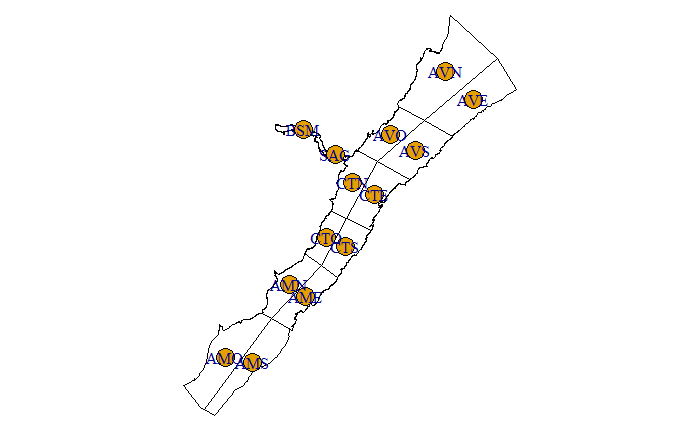

```r
df.sum$temp <- stringr::str_remove(stringr::str_remove(substr(rownames(df.sum),5,nchar(rownames(df.sum))-1), "muy"),"_Intercept")
df.sum$temp <- stringr::str_remove(stringr::str_remove(df.sum$temp, "muy"),"_Intercept")
df.sum<-cbind(df.sum,stringr::str_split_fixed(df.sum$temp, n=2, pattern=","))
df.sum$`1` <- stringr::str_remove(df.sum$`1`, "y")
df.sum$`2` <- stringr::str_remove(df.sum$`2`, "y")
colnames(df.sum)[9:10] <- c("from","to")
colnames(df.sum)[1] <- c("weight")

#create a network with edges that meet a given threshold requirement
df.sum$weight <- ifelse( ((df.sum$`l-95% CI`>0 & df.sum$`u-95% CI`>0) | (df.sum$`l-95% CI`<0 & df.sum$`u-95% CI`<0)), df.sum$weight, NA  )
graph.ranef<-igraph::graph_from_data_frame(dplyr::select(df.sum,from,to,weight ), directed=F)

#add colors and labels to the network
edge.col <- ifelse( E(graph.ranef)$weight>0,"green","red")
df.vertex<-as.data.frame(as.numeric(as.character(V(graph.ranef)$name)))
colnames(df.vertex)<-c("sec")
df.join<-left_join(df.vertex,df.sec.numb, by="sec")
node.label.out <- df.join$Secteur.de.la.position

#get map (shapefile) of the st. lawrence esturary
grid.area<-readOGR("../data/shapefile_sectors.shp")
trueCentroids = gCentroid(grid.area,byid=TRUE, id=grid.area$SECTEUR)
cent.sec<-as.data.frame(trueCentroids)
cent.sec$Secteur.de.la.position <- rownames(cent.sec)
node.latlong <-cent.sec

#get the right order for the sectors
node.latlong.join <- left_join(df.join,node.latlong, by="Secteur.de.la.position")

#adjust the coords for BSM and SAG
node.latlong.join[9,3] <- -69.976
node.latlong.join[9,4] <- 48.249

node.latlong.join[14,3] <- -69.778
node.latlong.join[14,4] <- 48.144

lo <- as.matrix(node.latlong.join[,3:4])

#take a look (with map)
par(mar = c(0, 0, 0, 0))
plot(grid.area)
plot(graph.ranef, edge.width=(abs(E(graph.ranef)$weight)*2), layout=lo, edge.color=edge.col, vertex.label = node.label.out, vertex.size= 12, rescale = FALSE, add=TRUE,vertex.label.cex=1)
```

```r
NA
NA
```

## 2.2) Partially structured data

Define 4 spatial communities

```r
#empty list
spatial_groups <- list()

#create 4 spatial groups each with associated sectors (in numeric form, e.g., SAG == 15)
spatial_groups[[1]] <- c(12,15,10)
spatial_groups[[2]] <- c(7,8,9)
spatial_groups[[3]] <- c(2,11,14)
spatial_groups[[4]] <- c(3,13,12)

#list of all sectors
all_sect <- c(12,15,10,7,8,9,2,11,14,3,13)
```

Simulate some data

```r
#get data where the sector associcated with a photoID has been randomly permuted
df.mag.sec <- read.csv("../data/photoID_perm.csv")

#get all IDs
x<-df.mag.sec$ID

#get 4 groups of IDs
split.values<-split(x, cut(x, quantile(x, prob = 0:4 / 4, names = FALSE), include = TRUE))

#for each photoID assign the sector associated with that individuals group 80% of the time, otherwise choose a sector at random.
for(i in 1:nrow(df.mag.sec)){
  ran_sec <- 0

  if(df.mag.sec$ID[i]<max(split.values[[1]])){
    ran_sec<-ifelse(runif(1)>0.2, sample(spatial_groups[[1]], size=1), sample(all_sect, size =1) )
  }else if(df.mag.sec$ID[i]<max(split.values[[2]])){
    ran_sec<-ifelse(runif(1)>0.2, sample(spatial_groups[[2]], size=1), sample(all_sect, size =1) )
  }else if(df.mag.sec$ID[i]<max(split.values[[3]])){
    ran_sec<-ifelse(runif(1)>0.2, sample(spatial_groups[[3]], size=1), sample(all_sect, size =1) )
  }else {
    ran_sec<-ifelse(runif(1)>0.2, sample(spatial_groups[[4]], size=1), sample(all_sect, size =1) )
  }

  df.mag.sec$sec[i] <- ran_sec

}

#take a look
table(df.mag.sec$sec)
```

```
   2    3    7    8    9   10   11   12   13   14   15
 629  652  635  648  670  619  637 1098  655  653  629
```

2.1) test out parially structured data on the multilevel binomial model

Get sector values for each NCT

```r
#for each individual count the number of times seen in each sector
df.mag.sec.multinom <- df.mag.sec %>% group_by(ID) %>% summarize(y2=sum(sec==2),
                                                                     y3=sum(sec==3),
                                                                     y7=sum(sec==7),
                                                                     y8=sum(sec==8),
                                                                     y9=sum(sec==9),
                                                                     y10=sum(sec==10),
                                                                     y11=sum(sec==11),
                                                                     y12=sum(sec==12),
                                                                     y13=sum(sec==13),
                                                                     y14=sum(sec==14),
                                                                     y15=sum(sec==15),
                                                                     ID=ID[1])
#for each individual count the total number of times seen
df.mag.sec.multinom$size <- with(df.mag.sec.multinom, y2 + y3 + y7 + y8 + y9 + y10 + y11 + y12 + y13 + y14 + y15)

#rename the dataframe
df.structured.multinom<-df.mag.sec.multinom
```

Fit multinomial

```r
#formula
bf_2 <- bf(y2 | trials(size) ~ 1 + (1|p|ID))+ binomial()
bf_3 <- bf(y3 | trials(size) ~ 1 + (1|p|ID))+ binomial()
bf_4 <- bf(y4 | trials(size) ~ 1 + (1|p|ID))+ binomial()
bf_5 <- bf(y5 | trials(size) ~ 1 + (1|p|ID))+ binomial()
bf_6 <- bf(y6 | trials(size) ~ 1 + (1|p|ID))+ binomial()
bf_7 <- bf(y7 | trials(size) ~ 1 + (1|p|ID))+ binomial()
bf_8 <- bf(y8 | trials(size) ~ 1 + (1|p|ID))+ binomial()
bf_9 <- bf(y9 | trials(size) ~ 1 + (1|p|ID))+ binomial()
bf_10 <- bf(y10 | trials(size) ~ 1 + (1|p|ID))+ binomial()
bf_11 <- bf(y11 | trials(size) ~ 1 + (1|p|ID))+ binomial()
bf_12 <- bf(y12 | trials(size) ~ 1 + (1|p|ID))+ binomial()
bf_13 <- bf(y13 | trials(size) ~ 1 + (1|p|ID))+ binomial()
bf_14 <- bf(y14 | trials(size) ~ 1 + (1|p|ID))+ binomial()
bf_15 <- bf(y15 | trials(size) ~ 1 + (1|p|ID))+ binomial()

#get priors
get_prior(bf_2+bf_3+bf_7+bf_8+bf_9+bf_10+bf_11+bf_12+bf_13+bf_14+bf_15 , data=df.structured.multinom)
```

```
Setting 'rescor' to FALSE by default for this model
```

| prior | class | coef | group | resp | dpar | nlpar | bound |
| --- | --- | --- | --- | --- | --- | --- | --- |
| lkj(1) | cor |  |  |  |  |  |  |
|  | cor |  | ID |  |  |  |  |
|  | Intercept |  |  |  |  |  |  |
| student_t(3, 0, 2.5) | Intercept |  |  | y10 |  |  |  |
| student_t(3, 0, 2.5) | sd |  |  | y10 |  |  |  |
|  | sd |  | ID | y10 |  |  |  |
|  | sd | Intercept | ID | y10 |  |  |  |
| student_t(3, 0, 2.5) | Intercept |  |  | y11 |  |  |  |
| student_t(3, 0, 2.5) | sd |  |  | y11 |  |  |  |
|  | sd |  | ID | y11 |  |  |  |

[output cut: 37 more lines]

```r
#fit the model
fit.int.structured.binom <- brm(bf_2+bf_3+bf_7+bf_8+bf_9+bf_10+bf_11+bf_12+bf_13+bf_14+bf_15, data=df.structured.multinom, cores=4,chains=4, iter=2000, control = list(adapt_delta=0.95)) # bf_4+bf_5+bf_6
```

```
Setting 'rescor' to FALSE by default for this model
```

```r
summary(fit.int.structured.binom)
```

```
 Family: MV(binomial, binomial, binomial, binomial, binomial, binomial, binomial, binomial, binomial, binomial, binomial)
  Links: mu = logit
         mu = logit
         mu = logit
         mu = logit
         mu = logit
         mu = logit
         mu = logit
         mu = logit
         mu = logit
         mu = logit
         mu = logit
Formula: y2 | trials(size) ~ 1 + (1 | p | ID)
         y3 | trials(size) ~ 1 + (1 | p | ID)
         y7 | trials(size) ~ 1 + (1 | p | ID)
         y8 | trials(size) ~ 1 + (1 | p | ID)
         y9 | trials(size) ~ 1 + (1 | p | ID)
         y10 | trials(size) ~ 1 + (1 | p | ID)
         y11 | trials(size) ~ 1 + (1 | p | ID)
         y12 | trials(size) ~ 1 + (1 | p | ID)
         y13 | trials(size) ~ 1 + (1 | p | ID)
         y14 | trials(size) ~ 1 + (1 | p | ID)
         y15 | trials(size) ~ 1 + (1 | p | ID)
   Data: df.structured.multinom (Number of observations: 821)
Samples: 4 chains, each with iter = 2000; warmup = 1000; thin = 1;
         total post-warmup samples = 4000

Group-Level Effects:
~ID (Number of levels: 821)
                                 Estimate Est.Error l-95% CI u-95% CI Rhat Bulk_ESS Tail_ESS
sd(y2_Intercept)                     1.78      0.11     1.59     2.01 1.00     1039     2094
sd(y3_Intercept)                     1.62      0.09     1.46     1.81 1.00     1783     2651
sd(y7_Intercept)                     1.57      0.10     1.39     1.78 1.00     1332     2371
sd(y8_Intercept)                     1.54      0.09     1.38     1.73 1.00     2002     2499
sd(y9_Intercept)                     1.56      0.09     1.39     1.75 1.00     1710     2454
sd(y10_Intercept)                    1.54      0.10     1.36     1.75 1.00     1746     1904
sd(y11_Intercept)                    1.71      0.10     1.52     1.91 1.00     1868     2342
sd(y12_Intercept)                    1.43      0.08     1.29     1.60 1.00     2010     2503
sd(y13_Intercept)                    1.62      0.09     1.45     1.80 1.00     2106     2769
sd(y14_Intercept)                    1.70      0.10     1.52     1.91 1.00     1433     2357
```

[output cut: 59 more lines]

```
y2_Intercept     -3.62      0.14    -3.91    -3.35 1.01      724     1396
y3_Intercept     -2.51      0.09    -2.69    -2.34 1.00     1257     2124
y7_Intercept     -3.89      0.14    -4.17    -3.62 1.00     1883     2420
y8_Intercept     -3.86      0.14    -4.14    -3.60 1.00     2123     2674
y9_Intercept     -3.85      0.14    -4.13    -3.60 1.00     1865     2849
y10_Intercept    -3.97      0.15    -4.28    -3.70 1.00     1971     1754
y11_Intercept    -3.50      0.13    -3.76    -3.25 1.00     1666     2699
y12_Intercept    -2.19      0.08    -2.36    -2.04 1.00     1770     2894
y13_Intercept    -2.47      0.09    -2.65    -2.30 1.00     1543     2263
y14_Intercept    -3.51      0.13    -3.77    -3.26 1.00     1432     2180
y15_Intercept    -4.17      0.16    -4.49    -3.87 1.00     2556     2944

Samples were drawn using sampling(NUTS). For each parameter, Bulk_ESS
and Tail_ESS are effective sample size measures, and Rhat is the potential
scale reduction factor on split chains (at convergence, Rhat = 1).
```

Plot the results of the dependence between the sectors

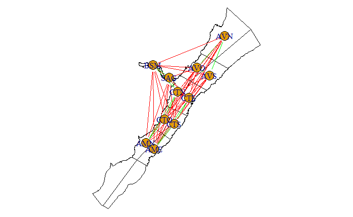

```r
grid.area<-readOGR("../data/shapefile_sectors.shp")
trueCentroids = gCentroid(grid.area,byid=TRUE, id=grid.area$SECTEUR)
cent.sec<-as.data.frame(trueCentroids)
cent.sec$Secteur.de.la.position <- rownames(cent.sec)
node.latlong <-cent.sec

#get the right order for the sectors
node.latlong.join <- left_join(df.join,node.latlong, by="Secteur.de.la.position")

#adjust the coords for BSM and SAG
node.latlong.join[6,3] <- -69.976
node.latlong.join[6,4] <- 48.249

node.latlong.join[11,3] <- -69.778
node.latlong.join[11,4] <- 48.144

lo <- as.matrix(node.latlong.join[,3:4])

#take a look (with map)
par(mar = c(0, 0, 0, 0))
plot(grid.area)
plot(graph.ranef, edge.width=(abs(E(graph.ranef)$weight)*2), layout=lo, edge.color=edge.col, vertex.label = node.label.out, vertex.size= 12, rescale = FALSE, add=TRUE,vertex.label.cex=1)
```